# K-means clustering in PyCuda

For this assignment, I will try to somehow implement the k means algorithm with GPU acceleration. First, a simple k means kernel is built to accelerate 2D distance and cluster estimation. Then this is extended to 3D space, tested, and compared with open cv function to asses performance.

```python
import math, matplotlib.pyplot as plt, operator, torch
import pycuda.autoinit
import pycuda.driver as drv
import numpy
from pycuda.compiler import SourceModule
import numpy as np
import cv2 as cv

from torch.distributions.multivariate_normal import MultivariateNormal
from torch import tensor
torch.set_printoptions(precision=3, linewidth=140, sci_mode=False)
```

## Create data

I know it is not necessary and consistency would be better but I will use both torch tensors and NumPy arrays to practice some transformations and functionalities. A set of toy data is generated first with PyTorch

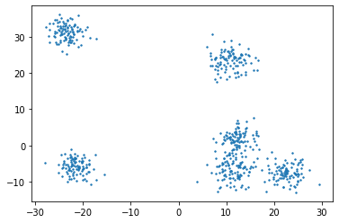

```python
def sample(m): return MultivariateNormal(m, torch.diag(tensor([5.,5.]))).sample((n_samples,))
n_clusters=6
n_samples =100
centroids = torch.rand(n_clusters, 2)*70-35
slices = [sample(c) for c in centroids]
data = torch.cat(slices)
plt.scatter(data[:,0],data[:,1],s=2)
```

# 2D k means

Now I define two functions to initialize k centers a completely random point generator and a k-means++ principle that aims to maximize the initial distance over the selected centers.

```python
def plus_plus(ds, k, random_state=42):
    """
    Create cluster centroids using the k-means++ algorithm.
    Parameters
    ----------
    ds : numpy array
        The dataset to be used for centroid initialization.
    k : int
        The desired number of clusters for which centroids are required.
    Returns
    -------
    centroids : numpy array
        Collection of k centroids as a numpy array.
    Inspiration from here: https://stackoverflow.com/questions/5466323/how-could-one-implement-the-k-means-algorithm
    """

    np.random.seed(random_state)
    centroids = [ds[0]]

    for _ in range(1, k):
        dist_sq = np.array([min([np.inner(c-x,c-x) for c in centroids]) for x in ds])
        probs = dist_sq/dist_sq.sum()
        cumulative_probs = probs.cumsum()
        r = np.random.rand()

        for j, p in enumerate(cumulative_probs):
            if r < p:
                i = j
                break

        centroids.append(ds[i])

    return np.array(centroids)


def random(ds, k, random_state=42):
    """
    Create random cluster centroids.

    Parameters
    ----------
    ds : numpy array
        The dataset to be used for centroid initialization.
    k : int
        The desired number of clusters for which centroids are required.
    Returns
    -------
    centroids : numpy array
        Collection of k centroids as a numpy array.
    """

    np.random.seed(random_state)
    centroids = []
    m = np.shape(ds)[0]

    for _ in range(k):
        r = np.random.randint(0, m-1)
        centroids.append(ds[r])

    return np.array(centroids)

def plot_data(centroids, data, n_samples):
    fig = plt.figure()
    ax = fig.add_subplot()
    for i, centroid in enumerate(centroids):
        samples = data[i*n_samples:(i+1)*n_samples]
        ax.scatter(samples[:,0], samples[:,1], s=1)
        ax.plot(*centroid, markersize=10, marker="x", color='k', mew=5)
        ax.plot(*centroid, markersize=5, marker="x", color='m', mew=2)

def plot_data3D(centroids, data, n_samples):
    fig = plt.figure(figsize=(10,10))
    ax = fig.add_subplot(projection='3d')
    for i, centroid in enumerate(centroids):
        samples = data[i*n_samples:(i+1)*n_samples]
        ax.scatter(samples[:,0], samples[:,1], samples[:,2], s=1)
        ax.plot(*centroid, markersize=10, marker="x", color='k', mew=5)
        ax.plot(*centroid, markersize=5, marker="x", color='m', mew=2)
```

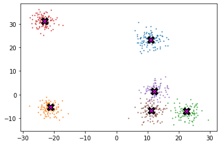

```python
plot_data(centroids, data, 100)
```

The kernel is a simple function, I define a one-dimensional grid with a one-dimensional block of N threads where N represents the total number of data samples to cluster. The kernel will estimate the distance between the point and each center and determine which is the minimum. The update of the centroids is done in CPU

```python
mod = SourceModule("""
__global__ void cluster_sub(float *dest, float *x,float *y,float *c_x,float *c_y, int N,int K)
{

  int threadId = blockIdx.x * blockDim.x + threadIdx.x;
  int index=0;

  if(threadId < N){
      float dist=sqrt(pow((x[threadId] - c_x[0]),2) + pow((y[threadId] - c_y[0]),2));
      for(int j=0 ; j<K; j++)
      {
          if(sqrt(pow((x[threadId] - c_x[j]),2) + pow((y[threadId] - c_y[j]),2))< dist){
              dist=sqrt(pow((x[threadId] - c_x[j]),2) + pow((y[threadId] - c_y[j]),2));
              index=j;
          }else {}

      dest[threadId]=index;
      }
  }
}
""")

cluster_sub = mod.get_function("cluster_sub")
```

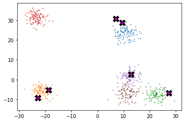

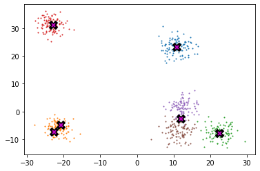

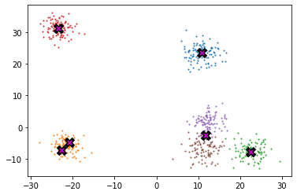

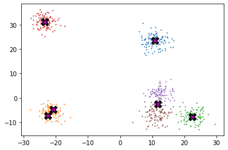

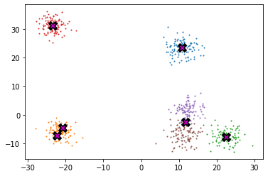

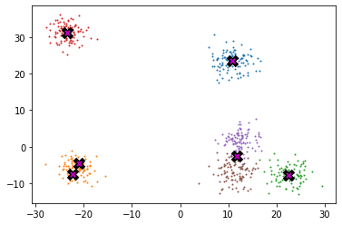

```python
#Random centroids
K=numpy.int32(6)

subset_x = data[:,0].numpy().copy(order='C')
subset_y = data[:,1].numpy().copy(order='C')
N=numpy.int32(subset_x.shape[0])
centroids = random(data.numpy(),K,random_state=42)
centroids_x = centroids[:,0].copy(order='C')
centroids_y = centroids[:,1].copy(order='C')
dest = numpy.zeros_like(subset_x)

for i in range (20):
    cluster_1=dest
    dest = numpy.zeros_like(subset_x)
    c=(numpy.stack([centroids_x.T,centroids_y.T],axis=1))
    plot_data(c, data, 100)
    cluster_sub(drv.Out(dest), drv.In(subset_x),drv.In(subset_y), drv.In(centroids_x),drv.In(centroids_y),N,K,block=(int(N),1,1), grid=(1,1))
    if numpy.all(dest==cluster_1):
        break
    else:
        centroids_x=numpy.array([numpy.mean(subset_x[dest==i]) for i in range(K)])
        centroids_y=numpy.array([numpy.mean(subset_y[dest==i]) for i in range(K)])
```